# Candidate fits for cumulative GPP allometry

## Purpose

This report is a separate, non-destructive follow-on to Report 28. It uses the same no-watershed-area cumulative GPP data, but starts by comparing four ways to describe the cumulative GPP–area relationship:

1. Linear regression in log10-log10 space.
2. Quadratic polynomial regression in log10-log10 space.
3. LOESS in log10-log10 space.
4. One-breakpoint segmented regression in log10-log10 space.

The four panels use the same data and log10 axes. The orange curve is the prediction from the model named in that panel.

## 1. Read the no-area-model GPP data

| median_slope | median_intercept | n_huc8_month_fits | n_huc8 |
| --- | --- | --- | --- |
| 1.481 | 2.045 | 22452 | 1871 |

## 2. Fit four candidate relationships

All models are fit on the log10-transformed variables. That is why a linear model in this report appears as a straight line on the log10-log10 plots.

| model | fit_on | segmented_breakpoint_km2 |
| --- | --- | --- |
| Linear | All reach-months | NA |
| Quadratic polynomial | All reach-months | NA |
| LOESS | 20,000 reach-month sample | NA |
| Segmented | All reach-months | 61.1 |

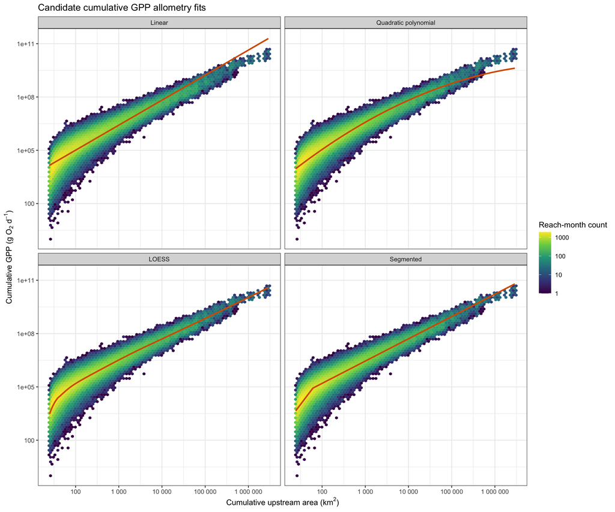

## 3. Evaluate each candidate function at HUC8 upstream areas

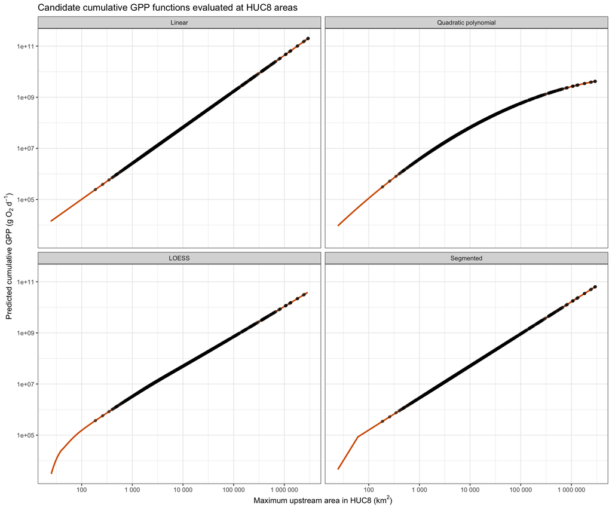

## 4. Area-normalized candidate projections

For each candidate, cumulative GPP is divided by the same cumulative upstream area plotted on the x-axis. The resulting y-axis is g O<sub>2</sub> km<sup>-2</sup> d<sup>-1</sup>.

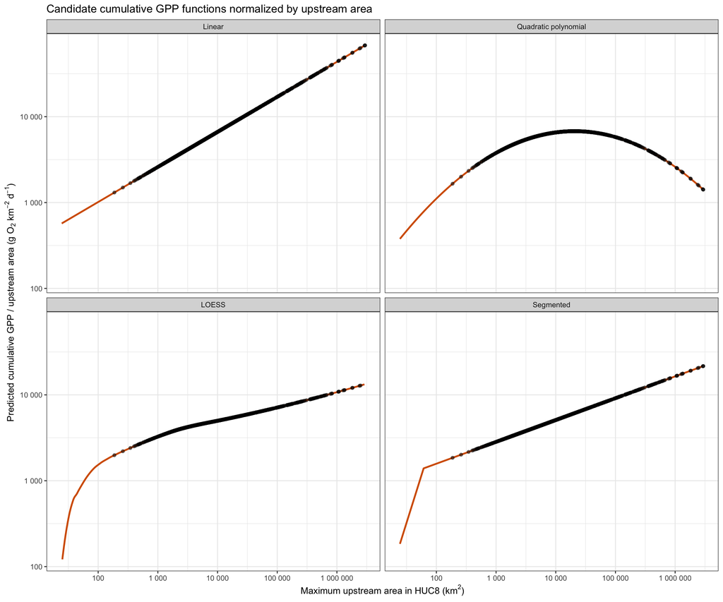

## 5. Area-normalized candidate projections over observed data

This repeats the normalized candidate curves, but now the background is the observed reach-month cumulative GPP divided by its own cumulative upstream area.

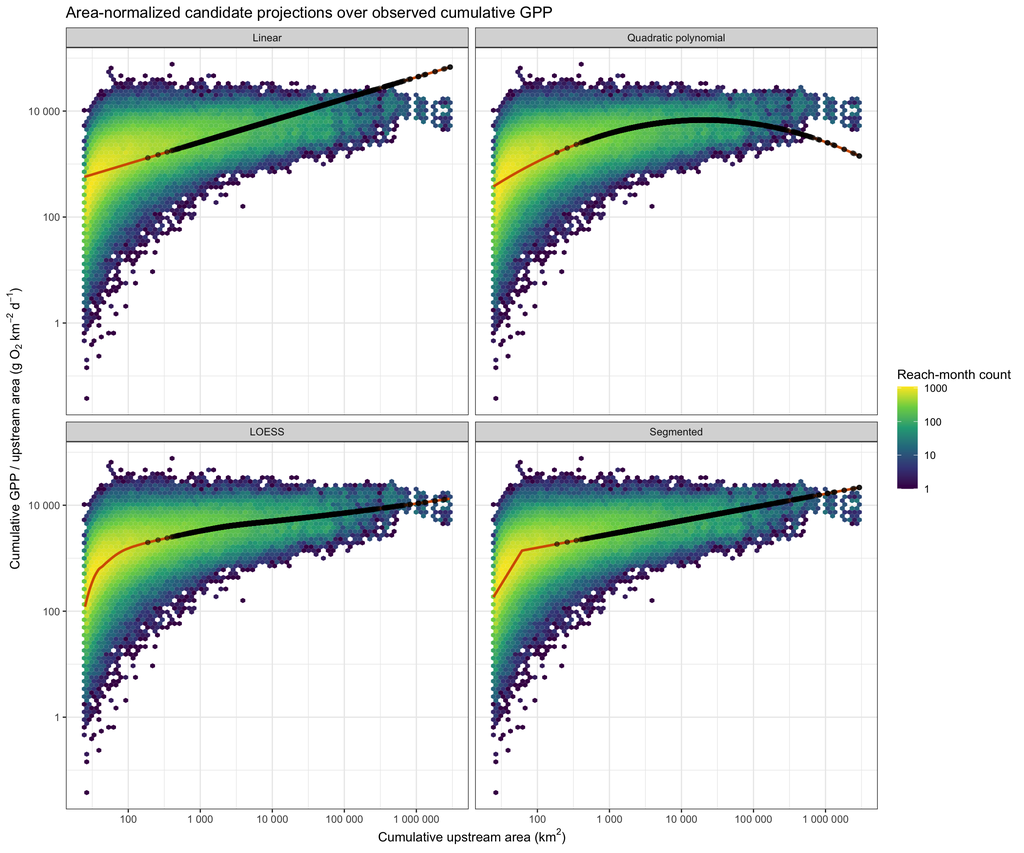

## 6. Area-normalized candidates on linear axes

This is the same observed-data overlay as Section 5 without log10 scale transformations. The dashed line is the requested 1:1 reference line.

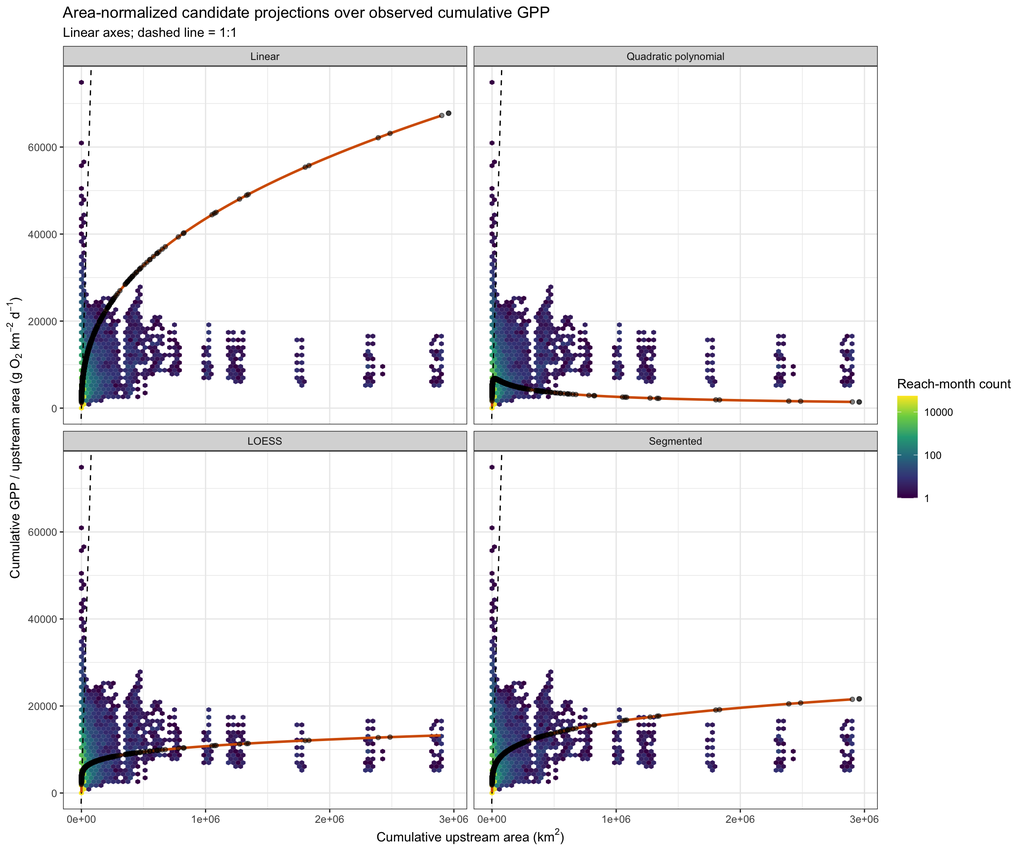

## 7. LOESS-only version of Section 6 with selected river mouths

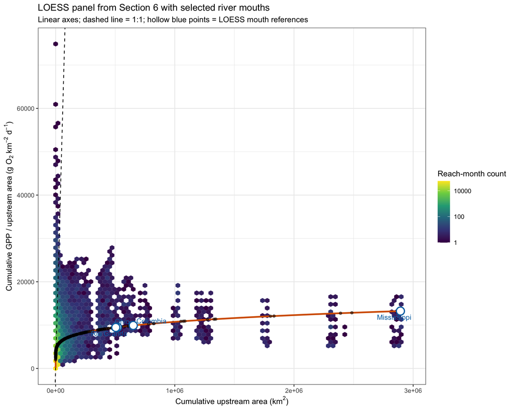

## 8. LOESS panel extended to global rivers larger than the Mississippi

This global-context version retains only the Columbia and Mississippi U.S. mouth markers. Purple hollow points are the Amazon, Congo, and Ob–Irtysh on the dashed extrapolated extension.

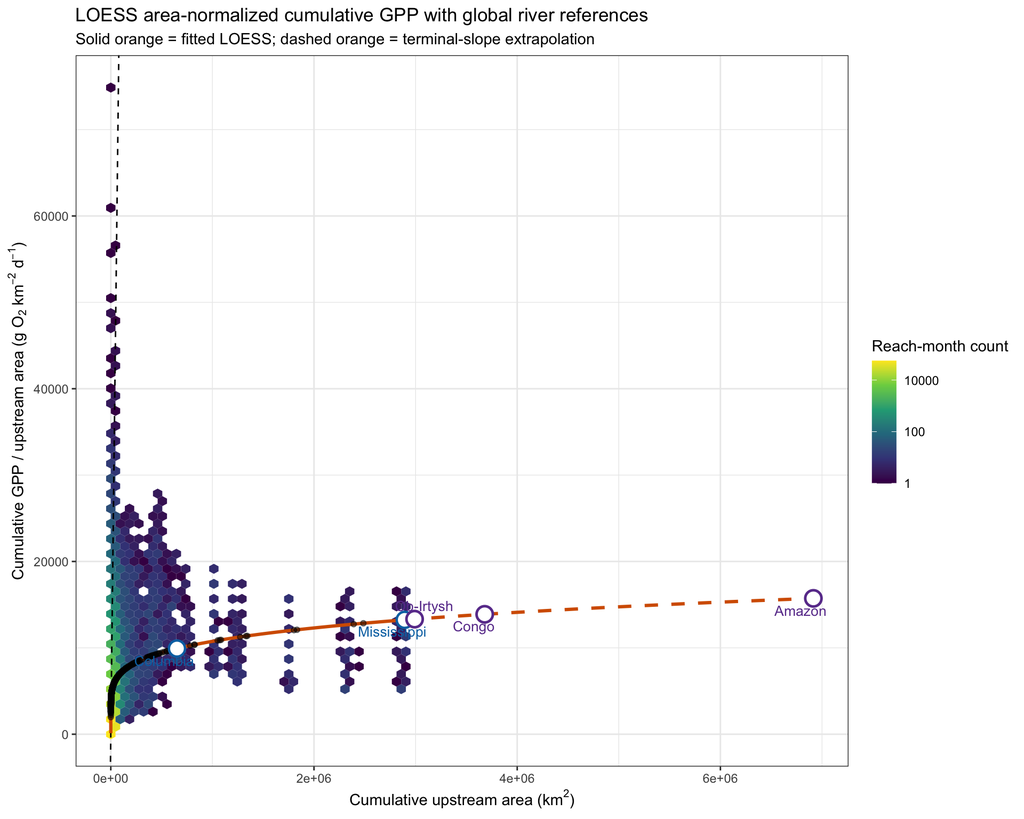

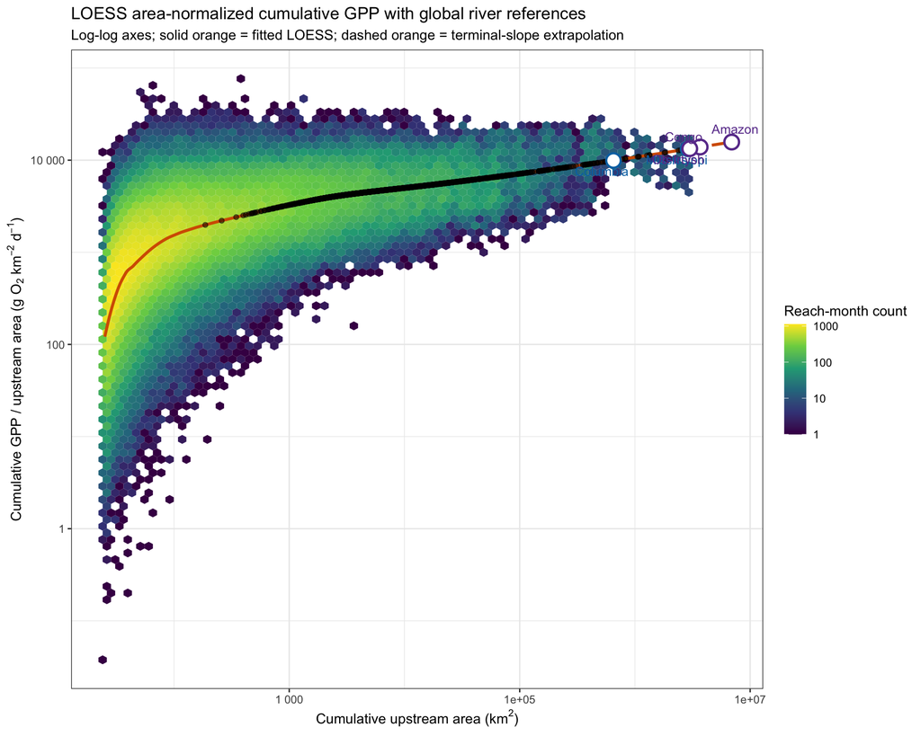

## 9. Segmented-regression global river references

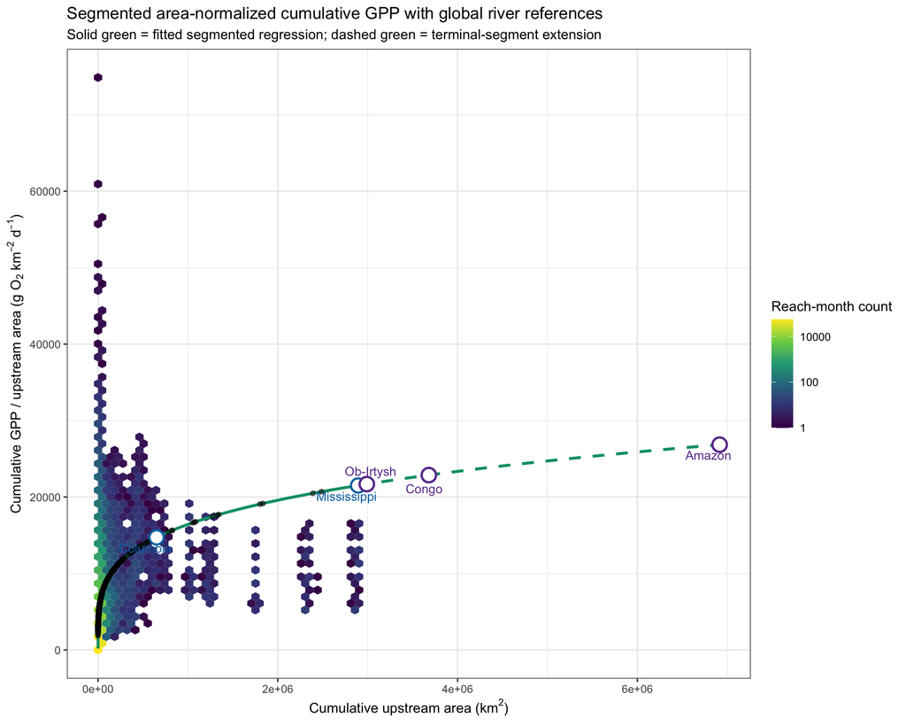

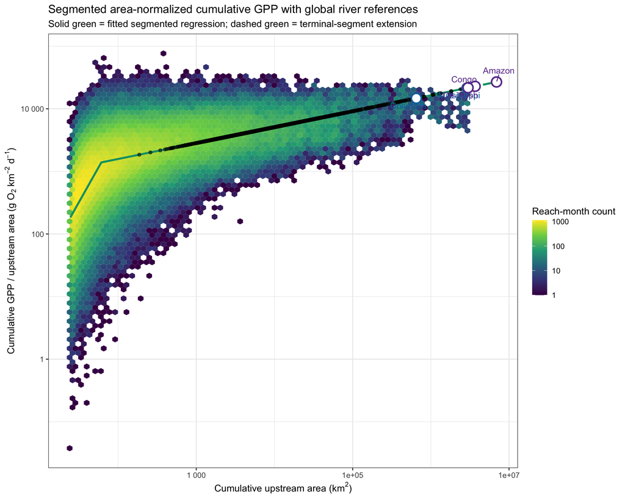